# Machine learning II. Series temporales

Natalia Alonso, Beatriz Visitación y Susana Albarrán

14/07/2020

# 1 Introducción

Los datos que se van a analizar en este proyecto han sido obtenidos desde Kaggle: https://www.kaggle.com/gustavomodelli/forest-fires-in-brazil. Continene el número de incendios por zona en Brasil (Amazonas) por meses desde 1998 hasta 2017.

# 2 Objetivo del estudio

El objetivo de este estudio es analizar una serie temporal para poder construir un modelo con el fin de predecir el número de incendios que tendrán lugar en el futuro, basándonos en los datos recogidos en años anteriores.

# 3 Datos

En primer lugar, se cargan los datos, este dataset tiene los siguientes campos:

- **year**: año en que se produjo el incendio.
- **state**: nombre del estado donde se produjo el incendio.
- **month**: mes en el que se produjo el incendio.
- **number**: número de incendios.
- **date**: fecha exacta en que se produjo el incendio.

Para el estudio que se va a realizar, se seleccionan los campos: **year, month y number**. Se convierte el valor del campo **month**, que inicialmente está en portugués a inglés. Se agrupa por mes y año y se halla el recuento. Finalmente, se decide agrupar por trimestres y obtener el recuento por trimestres para cada año.

```r
data_all <- data %>%
  select(year, month, number) %>%
  mutate(month = if_else(month == "Abril", "Apr",
                 if_else(month == "Agosto", "Aug",
                 if_else(month == "Dezembro", "Dec",
                 if_else(month == "Fevereiro", "Feb",
                 if_else(month == "Janeiro", "Jan",
                 if_else(month == "Julho", "Jul",
                 if_else(month == "Junho", "Jun",
                 if_else(month == "Maio", "May",
                 if_else(month == "Setembro", "Sep",
                 if_else(month == "Novembro", "Nov",
                 if_else(month == "Outubro", "Oct", "Mar")))))))))))) %>%
  mutate(new_date = as.yearmon(paste(month, "-", year), "%B - %Y")) %>%
  group_by(new_date) %>%
  summarise(total = sum(as.integer(number))) %>%
  mutate(new_quarter = quarter(new_date, with_year = TRUE)) %>%
  group_by(new_quarter) %>%
  summarise(total_quarter = sum(as.integer(total)))
```

Se almacena la serie como un objeto tsibble en R y se realiza una representación de la serie temporal resultante con el recuento por trimestre. Se decide filtrar los datos y continuar con los recuentos comprendidos entre el primer trimestre de 1998, y el último de 2014 sin aplicar filtro por región.

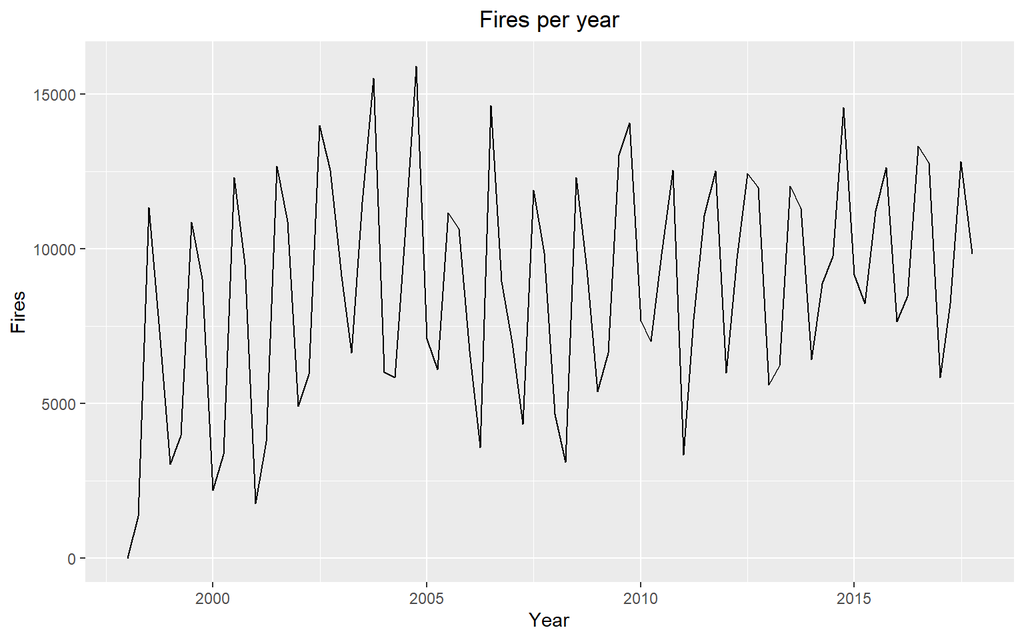

```r
ts_data_all<- ts(data_all$total_quarter, start = c(1998,1), frequency = 4)
fires <- as_tsibble(ts_data_all, index = new_quarter)

fires %>%
  autoplot(value) +
  labs(title = "Fires per year") +
  xlab("Year") + ylab("Fires") +
  theme(plot.title = element_text(hjust = 0.5))
```

```r
fires <- fires %>% filter_index("1998 Q1" ~ "2014 Q4")
```

# 4 División train y test

Se divide el conjunto de datos en train (entre 1999 y 2011) y test (2012 y 2014).

```r
fires_train <- fires %>% filter_index("1999 Q1" ~ "2011 Q4")
fires_test <- fires %>% filter_index("2012 Q1" ~ "2014 Q4")
```

# 5 Análisis exploratorio

A continuación, se realiza un análisis exploratorio de la serie temporal, representando:

- **Gráfica global mensual para cada año.** Parece que hay una componente estacional anual, dado que la forma de las series anuales son parecidas.
- **Gráfica por trimestres.** Se puede observar que existe un patrón estacional. Las líneas azules indican el número promedio de incendios en cada trimestre, lo que hace que el aumento en los incendios en el Q3 y Q4 sea más obvio. El número de incendios en Q3 y Q4 aumentan mucho más que en Q1 y Q2, esto sugiere que la tendencia puede variar entre las estaciones.
- **Gráfica de dispersión del retardo**, para ver la relación entre los valores y los valores aplicando un cierto retardo. Se ve que los valores se ajustan mejor cuando se aplica un retardo de cuatro.

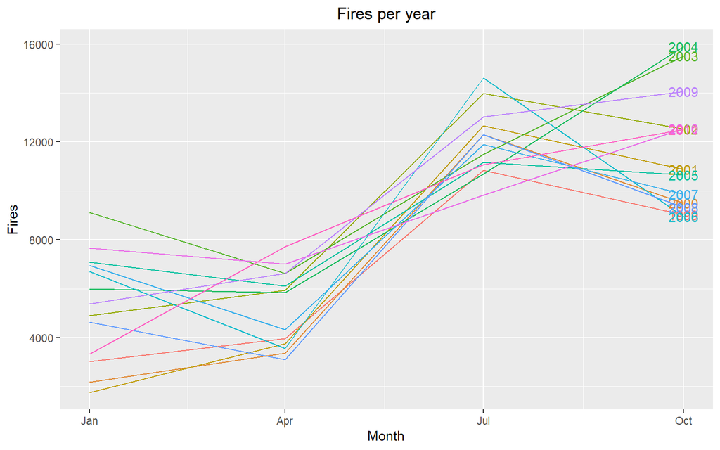

```r
# Gráfica con todos los años:
fires_train %>% gg_season(value, labels = "right")+
  labs(title = "Fires per year") +xlab("Month") + ylab("Fires") +
  theme(plot.title = element_text(hjust = 0.5))
```

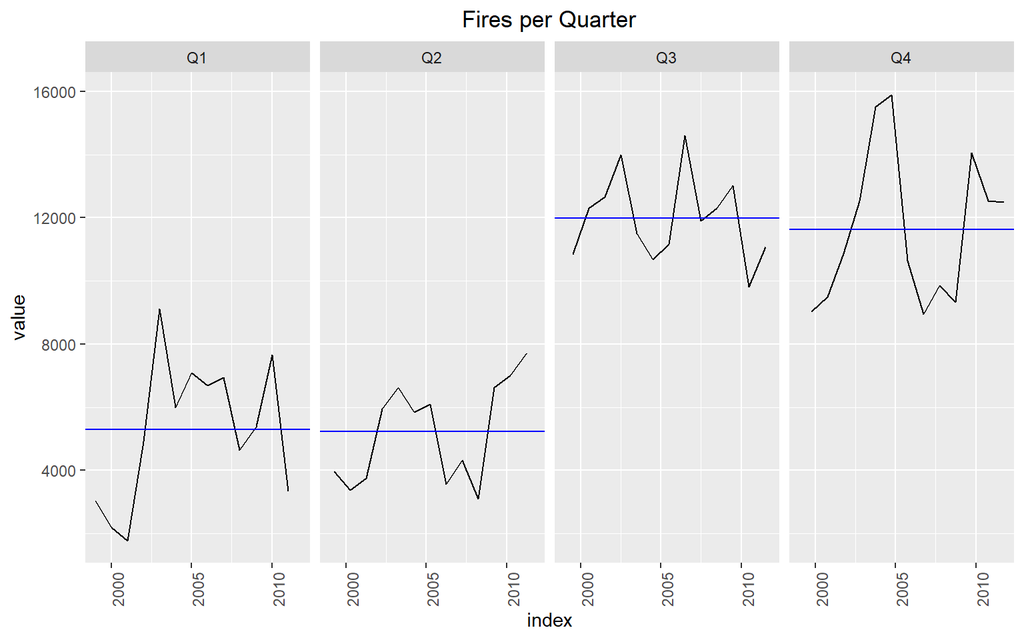

```r
# Gráfica por trimestres:
fires_train %>% gg_subseries(value)+
  labs(title = "Fires per Quarter")+
  theme(plot.title = element_text(hjust = 0.5))
```

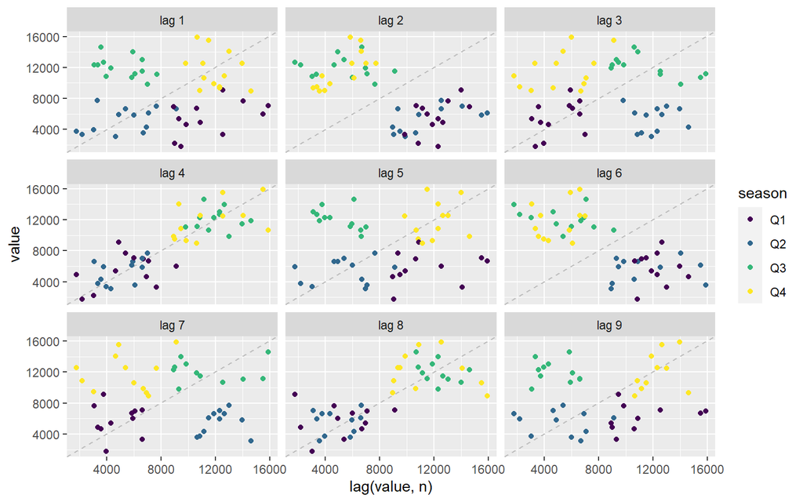

```r
# Gráficos de retardo:
fires_train %>% gg_lag(value, geom="point")
```

## 5.1 Descomposición de la señal: STL

- Se analiza también la serie con su descomposición en **tendencia**, **estacionalidad** y **componente aleatoria**.

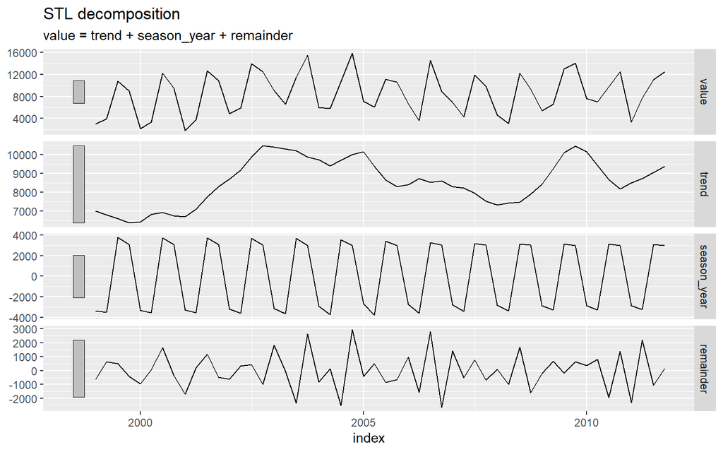

```r
fires_train %>%
  model(seats = feasts:::STL(value)) %>%
  components() %>%
  autoplot()
```

## 5.2 Estacionariedad en varianza

Para comprobar la estacionariedad en varianza se aplica el test de lambda guerrero. El valor de lambda es de 1.30, y por tanto, se decide no realizar ninguna transformación.

```r
lambda <- fires_train %>%
  features(value, features = guerrero) %>%
  pull(lambda_guerrero)
lambda
```

```
## [1] 1.30318
```

## 5.3 Estacionariedad en media

```r
fires_train %>% features(value, unitroot_kpss)
```

```
## # A tibble: 1 x 2
##   kpss_stat kpss_pvalue
##       <dbl>       <dbl>
## 1     0.393      0.0803
```

Se aplica una diferencia de una unidad y se repite el test, ahora el p_valor asciende a 0.1. Se asume que será necesario aplicar una diferencia de una unidad.

```r
fires_train %>% features(difference(value, 1), unitroot_kpss)
```

```
## # A tibble: 1 x 2
##   kpss_stat kpss_pvalue
##       <dbl>       <dbl>
## 1     0.190         0.1
```

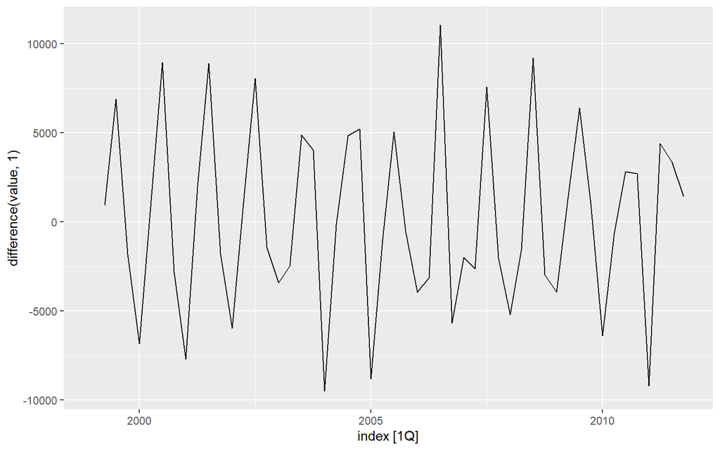

```r
fires_train %>% autoplot(difference(value, 1))
```

A continuación, se evalúa el estadístico fuerza estacional FS, este estadístico, sugiere una diferencia estacional si ésta es mayor que 0.64, como es este caso.

```r
fires_train %>%
  mutate(log_turnover = difference(value,1)) %>%
  features(log_turnover, unitroot_nsdiffs)
```

```
## # A tibble: 1 x 1
##   nsdiffs
##     <int>
## 1       1
```

# 6 Modelo autoregresivo: SAR

## 6.1 Determinación del modelo

A continuación, se analiza la autocovarianza **total**: ACF, y **parcial**: PACF, para determinar el orden p (AR) mediante la gráfica PACF, y el orden q (MA) con la gráfica ACF.

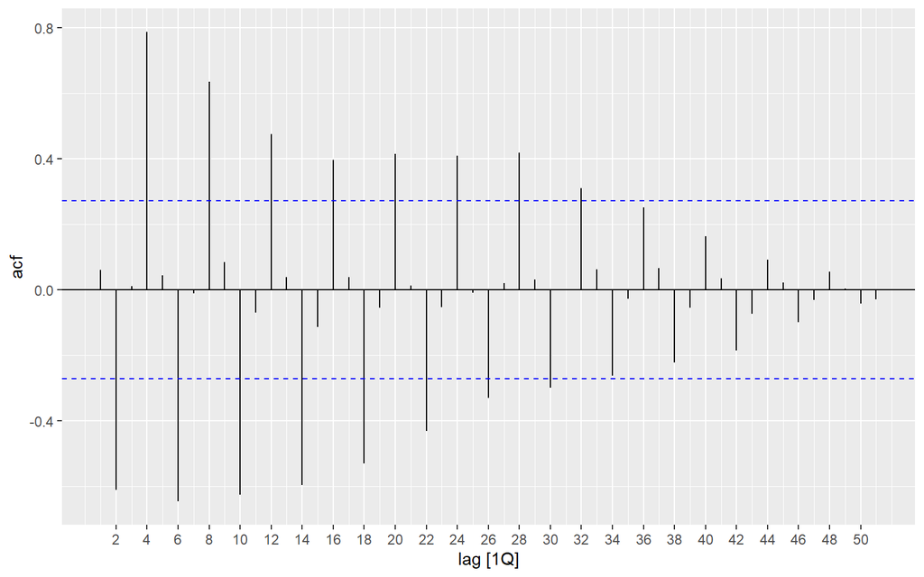

```r
# autocovarianza de la serie temporal: ACF

fires_train %>%
  ACF(value, lag_max = 100) %>%
  autoplot()
```

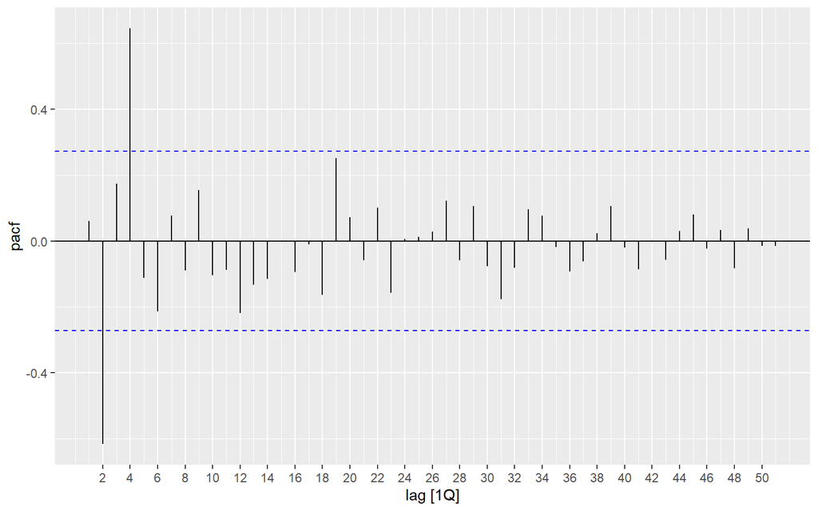

```r
# autocovarianza parcial de la serie temporal: PACF
fires_train %>%
  PACF(value, lag_max = 100) %>%
  autoplot()
```

Con la información extraída de las gráficas anteriores, se implementa un modelo SAR (con parámetros [p,d,q] = [0,0,0], [P,D,Q] = [1,0,0] y un periodo = 4). También se ajustaron otros modelos y se comparó el rendimiento, finalmente se decide seleccionar el anteriormente mencionado dados los resultados de la evaluación.

```r
# Modelo manual: AR + SAR (SAR)4: pdq(1,0,0) + PDQ(1,0,0),
# fit_manual <- fires_train %>% model(arima = ARIMA(box_cox(value, lambda) ~ pdq(1,0,0) + PDQ(1,0,0, period = 4)))
# report(fit_manual)

# Modelo manual: AR + SAR + MA + SMA (SARMA)4: pdq(1,0,1) + PDQ(1,0,1)
# fit_manual <- fires_train %>% model(arima = ARIMA(box_cox(value, lambda) ~ pdq(1,0,1) + PDQ(1,0,1, period = 4)))
# report(fit_manual)

# Modelo manual: SAR (SAR)4: pdq(0,0,0) + PDQ(1,0,0)
fit_manual <- fires_train %>% model(arima = ARIMA(box_cox(value, lambda) ~ pdq(0,0,0) + PDQ(1,0,0, period = 4)))
report(fit_manual)
```

```
## Series: value
## Model: ARIMA(0,0,0)(1,0,0)[4] w/ mean
## Transformation: box_cox(.x, lambda)
##
## Coefficients:
##         sar1   constant
##       0.8333  16700.913
## s.e.  0.0670   3300.738
##
## sigma^2 estimated as 1.036e+09:  log likelihood=-614.85
## AIC=1235.71   AICc=1236.21   BIC=1241.56
```

El criterio de información de Akaike usado para medir la calidad relativa de modelos estadísticos, tiene como resultado un valor de 1236 unidades.

## 6.2 Diagnosis del modelo

Para la diagnosis del modelo se va a realizar un análisis de la significancia de los coeficientes y un análisis de residuos.

### 6.2.1 Análisis de los coeficientes

Se realiza un test para analizar si los coeficientes son significativos. Se obtiene un p_valor muy cercano a cero para los dos coeficientes (sar1 y la constante), por lo que se rechaza la hipótesis nula y se concluye que los coeficientes son significativos.

```r
t_stat <- tidy(fit_manual)$statistic
p_value <- tidy(fit_manual)$p.value # h0 es que el coef es 0. como p es 0, se rechaza, entonces es significativo
rbind(t_stat, p_value)
```

```
##                 sar1     constant
## t_stat  1.244192e+01 5.059752e+00
## p_value 3.264229e-17 5.586098e-06
```

### 6.2.2 Análisis de residuos

Como se aprecia en los gráficos los residuos siguen una distribución normal y la media parece constante.

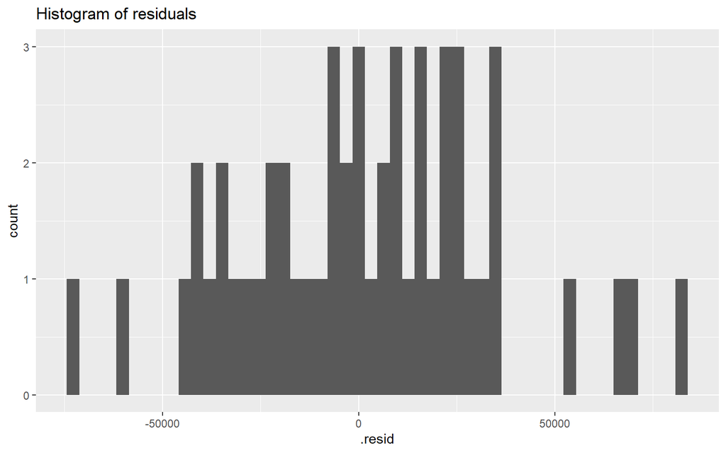

```r
aug <-fit_manual %>% augment()

aug %>%
  ggplot(aes(x = .resid)) +
  geom_histogram(bins = 50) +
  ggtitle("Histogram of residuals")
```

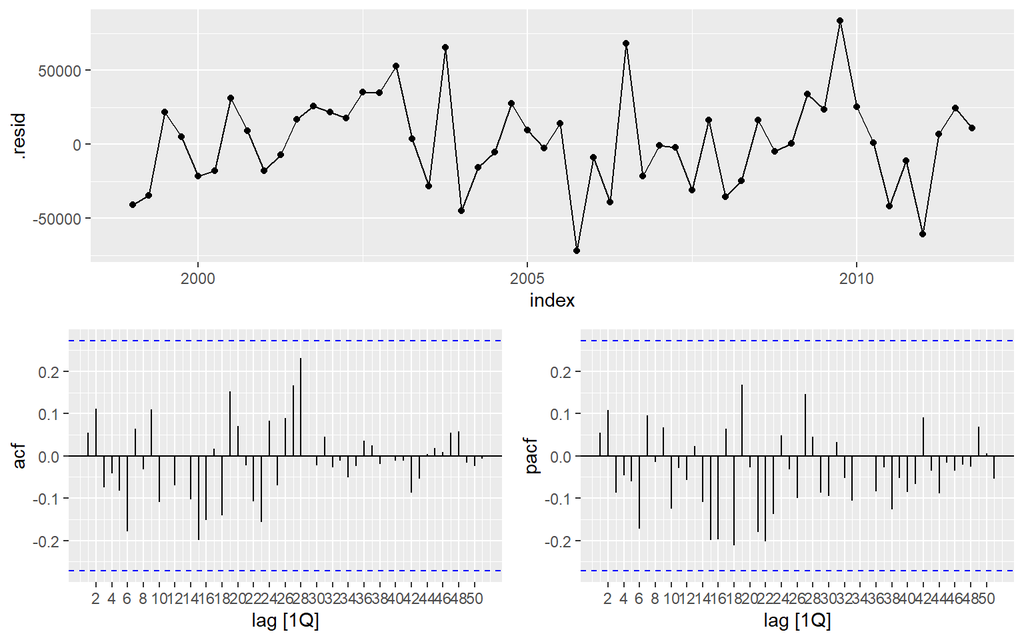

```r
residual <- stats::residuals(fit_manual)
gg_tsdisplay(residual,!!sym(".resid"), plot_type = "partial", lag_max = 90)
```

#### 6.2.2.1 Test para la media

Al realizar el test de normalidad de los residuos, se concluye que efectivamente, como indica el p_valor (0,62), la media de los residuos es cero.

```r
t.test(aug$.resid)
```

```
##
##  One Sample t-test
##
## data:  aug$.resid
## t = 0.49441, df = 51, p-value = 0.6231
## alternative hypothesis: true mean is not equal to 0
## 95 percent confidence interval:
##  -6670.71 11029.90
## sample estimates:
## mean of x
##  2179.594
```

#### 6.2.2.2 Test de autocorrelaciones

Para comprobar si los residuos están incorrelados se realiza el test de ljung_box. El p_valor es igual a 0.78, y por tanto, se acepta que los residuos son incorrelados.

```r
aug %>% features(.resid, ljung_box, lag=8, dof=1)
```

```
## # A tibble: 1 x 3
##   .model lb_stat lb_pvalue
##   <chr>    <dbl>     <dbl>
## 1 arima     3.96     0.784
```

#### 6.2.2.3 Test homocedasticidad

Para comprobar si los residuos son constantes en varianza, se realiza el test de homocedasticidad. Se obtiene un p_valor de 0.41 y se acepta que, en efecto, los residuos son homocedásticos.

```r
log_log <- aug %>% as_tibble() %>%
  group_by(quarter(index)) %>%
  summarize(mean_resid = (mean(.resid+1)), std_resid = (sd(.resid+1)))

summary(lm(std_resid~mean_resid, log_log))
```

```
##
## Call:
## lm(formula = std_resid ~ mean_resid, data = log_log)
##
## Residuals:
##     1     2     3     4
##  6117 -6821 -3404  4108
##
## Coefficients:
##              Estimate Std. Error t value Pr(>|t|)
## (Intercept) 2.954e+04  3.837e+03   7.699   0.0165 *
## mean_resid  3.867e-01  3.763e-01   1.028   0.4122
## ---
## Signif. codes:  0 '***' 0.001 '**' 0.01 '*' 0.05 '.' 0.1 ' ' 1
##
## Residual standard error: 7497 on 2 degrees of freedom
## Multiple R-squared:  0.3456, Adjusted R-squared:  0.01835
## F-statistic: 1.056 on 1 and 2 DF,  p-value: 0.4122
```

## 6.3 Predicción

Se predice el número de incendios para los años 2012, 2013 y 2014, y se compara gráficamente los indencios reales frente a los predichos.

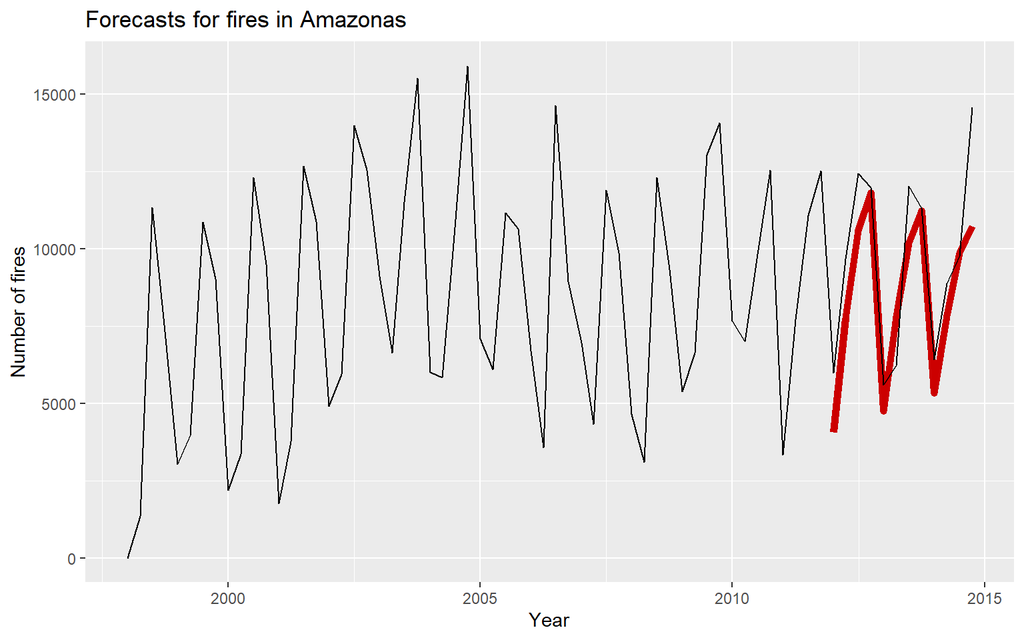

```r
# Residual accuracy
resids <- fit_manual %>%
  accuracy() %>%
  select(-c(.model, .type, ME, MPE, ACF1 )) %>%
  mutate(Evaluation='Training')

# Forecasting
fc <- fit_manual %>%
  forecast(h=12)

fc %>%
  autoplot(fires, level = NULL, col="red", lwd = 2) +
  ggtitle("Forecasts for fires in Amazonas") +
  xlab("Year") + ylab("Number of fires")
```

## 6.4 Evaluación del modelo

Para la evaluación del modelo, se usan las siguientes métricas:

- res: diferencia entre el valor predicho y el real.
- MAE: error absoluto medio.
- MAE_std: desviación típica del error absoluto medio.
- MAPE: error porcentual absoluto medio.
- MAPE_std: desviación típica del error porcentual absoluto medio.
- MSE: error cuadrático medio.
- MSE_std: desviación del error cuadrático medio.
- RMSE: La raíz del error cuadrático medio.
- RMSE_std: desviación de la raiz del error cuadrático.

```r
getPerformance = function(pred, val) {
  res = pred - val
  MAE = sum(abs(res))/length(val)
  MAE_std = sd(abs(res))
  MAPE = mean(100*abs(res)/val)
  MAPE_std = sd(100*abs(res)/val)
  MSE = sum(res^2)/length(val)
  MSE_std = sd((res)**2)
  RMSE = sqrt(MSE)
  RMSE_std = sqrt(MSE_std)
  perf = data.frame(MAE,MAE_std,MAPE,MAPE_std,RMSE,RMSE_std)
}

accuracy_train_manual <-getPerformance(aug$.fitted,fires_train$value) %>%
  mutate(Evaluation='Train manual')

accuracy_test_manual <-getPerformance(fc$value,fires_test$value) %>%
  mutate(Evaluation='Test manual')

# Show errors together
bind_rows(accuracy_train_manual, accuracy_test_manual) %>% select(Evaluation, everything())
```

```
##     Evaluation      MAE  MAE_std     MAPE MAPE_std     RMSE RMSE_std
## 1 Train manual 1617.443 1224.099 26.23692 29.70188 2021.317 2337.276
## 2  Test manual 1350.536 1061.033 15.01943 10.24210 1689.947 2005.939
```

Por último, se representa la relación entre el valor real y el predicho, para el conjunto de train para cada año (entre 1999 y 2011).

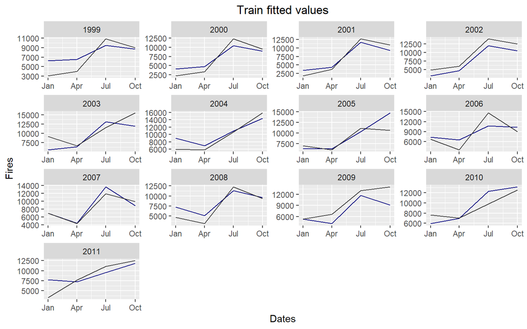

```r
aug %>%  ggplot() +
  geom_line(aes(x = index, y = .fitted), color="navy") +
  geom_line(aes(x = index, y = value), color="gray24") +
  ggtitle("Train fitted values") +
  xlab('Dates') +
  ylab('Fires') + facet_wrap(vars(year(index)), scales = 'free') +
  theme(plot.title = element_text(hjust = 0.5))
```

De manera general, el valor predicho es similar al valor real. Hay diferencias en el 2006, 2010 y a comienzos del primer trimestre de 2011.

## 6.5 Comparación entre ajuste manual y automático

Por último, se compara el ajuste manual realizado para un modelo SAR con todas las regiones en conjunto, con un modelo ARIMA automático, por cada región y sumando las diferentes predicciones.

```r
regiones <- unique(data$state)
prediccion_regiones <- data.frame()

for (region in regiones){
  data_region <- data %>%
    filter(state == region) %>%
    select(year, month, number) %>%
    mutate(month = if_else(month == "Abril", "Apr",
                   if_else(month == "Agosto", "Aug",
                   if_else(month == "Dezembro", "Dec",
                   if_else(month == "Fevereiro", "Feb",
                   if_else(month == "Janeiro", "Jan",
                   if_else(month == "Julho", "Jul",
                   if_else(month == "Junho", "Jun",
                   if_else(month == "Maio", "May",
                   if_else(month == "Setembro", "Sep",
                   if_else(month == "Novembro", "Nov",
                   if_else(month == "Outubro", "Oct", "Mar")))))))))))) %>%

    mutate(new_date = as.yearmon(paste(month, "-", year), "%B - %Y")) %>%
    group_by(new_date) %>%
    summarise(total = sum(as.integer(number))) %>%
    mutate(new_quarter = quarter(new_date, with_year = TRUE)) %>%
    group_by(new_quarter) %>%
    summarise(total_quarter = sum(as.integer(total)));


  ts_data_region<- ts(data_region$total_quarter, start = c(1998,1), frequency = 4)
  fires_region <- as_tsibble(ts_data_region, index = new_quarter)

  fires_region <- fires_region %>% filter_index("1999 Q1" ~ "2014 Q4")

  # Dividir en train y test:

  fires_train_region <- fires_region %>% filter_index("1999 Q1" ~ "2011 Q4")
  fires_test_region <- fires_region %>% filter_index("2012 Q1" ~ "2014 Q4")

  fit_automatico_region <- fires_train_region %>% model(arima = ARIMA(value))

  fc_region <- fit_automatico_region %>%
    forecast(h=12)

  prediccion_regiones <- rbind(prediccion_regiones, fc_region$value)
}
```

Por último, se comparan ambos modelos. Para el conjunto de test con el modelo manual sobre toda la región se obtiene un MAPE de 15%. Con el modelo autómatico región a región y sumando las predicciones, un 13%.

```r
colnames(prediccion_regiones) <- c("Q1 2012","Q2 2012","Q3 2012","Q4 2012","Q1 2013","Q2 2013","Q3 2013","Q4 2013","Q1 2014","Q2 2014","Q3 2014","Q4 2014")


predioccion_regiones_all <- colSums(prediccion_regiones)

accuracy_test_automatico <-getPerformance(predioccion_regiones_all,fires_test$value) %>%
  mutate(Evaluation='Test automatico')

# Show errors together
bind_rows(accuracy_test_manual, accuracy_test_automatico) %>% select(Evaluation, everything())
```

```
##        Evaluation      MAE  MAE_std     MAPE MAPE_std     RMSE RMSE_std
## 1     Test manual 1350.536 1061.033 15.01943  10.2421 1689.947 2005.939
## 2 Test automatico 1280.786 1095.297 13.27673  11.3553 1655.329 1896.219
```

```r
cat("Número real de indencios en los 8 quarters, en todas las regiones: ", sum(fires_test$value),"\n")
```

```
## Número real de indencios en los 8 quarters, en todas las regiones:  114796
```

```r
cat("Predicción del número de indencios en los 8 quarters, en todas las regiones con el modelo manual: ", sum(fc$value),"\n")
```

```
## Predicción del número de indencios en los 8 quarters, en todas las regiones con el modelo manual:  101913
```

```r
cat("Predicción del número de indencios en los 8 quarters, en todas las regiones con el modelo automático: ", sum(prediccion_regiones),"\n")
```

```
## Predicción del número de indencios en los 8 quarters, en todas las regiones con el modelo automático:  103975.5
```

# 7 Modelo red neuronal: ELMAN

## 7.1 División en train y test

En primer lugar, para la implementación de la red neuronal, se normalizan los datos y se divide el conjunto total en train y test:

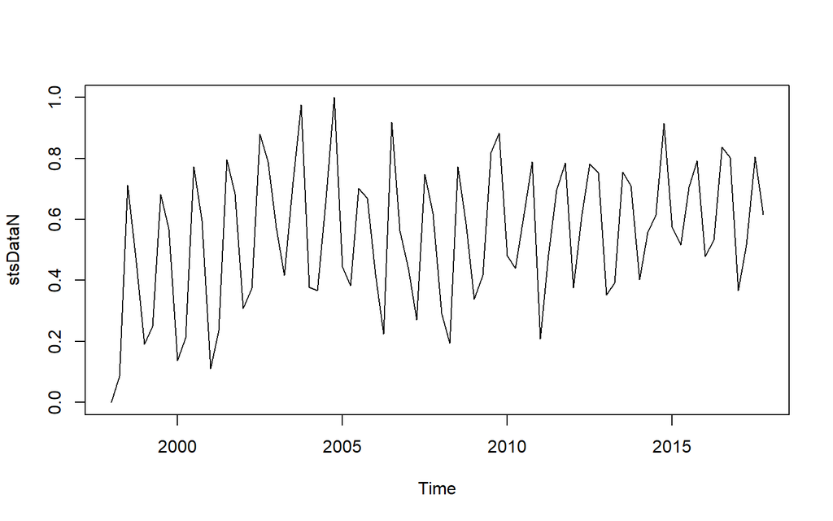

```r
# Se normaliza:
stsDataN <- (ts_data_all-min(ts_data_all))/(max(ts_data_all)-min(ts_data_all))
plot(stsDataN)
```

```r
set.seed(1)

tamano_total <- length(stsDataN) - 4
tamano_train <- tamano_total - 8
train <- 1:(tamano_train)
test<-(tamano_train+1):(tamano_total)
```

## 7.2 Cálculo de inputs y outputs

A continuación, se crea un nuevo dataframe para añadir nuevas variables cada una de las cuales será un valor de la serie en el pasado (retardo), a través de una variable de tipo zoo. Por último, se eliminan los NAs que se han creado al aplicar esta operación. Ya que, por ejemplo, para la primera muestra no se cuenta con ningún valor pasado. Como se van a considerar 4 retardos, se eliminan las 4 primeras filas.

```r
y<-as.zoo(stsDataN)

x1<-Lag(y,k=1)
x2<-Lag(y,k=2)
x3<-Lag(y,k=3)
x4<-Lag(y,k=4)

slogN<-cbind(y,x1,x2,x3,x4)

stsData_lag<-slogN[-c(1:4),]
```

Después se establecen los inputs y el output para la red neuronal. Los inputs serían los retardos, y el output, la variable respuesta, es decir, el valor actual (que se pretende estimar con los 4 valores anteriores o retardos).

```r
inputs<-stsData_lag[,2:5]
outputs<-stsData_lag[,1]
```

## 7.3 Determinación del modelo

Se implementa el modelo basado en una red neuronal de Elman y se representa el error para cada iteracción hasta el máximo de iteraciones definidas mediante el parámetro maxit.

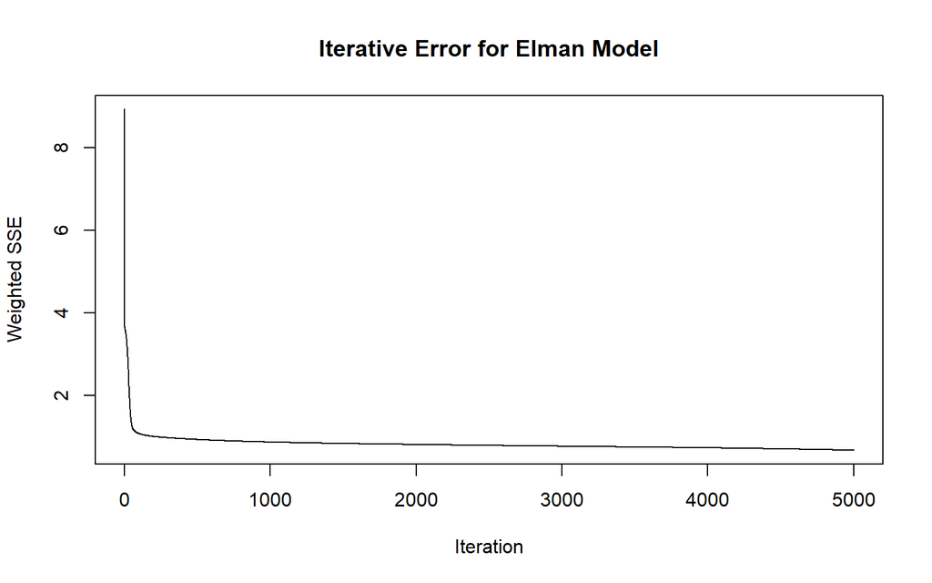

```r
fit<-elman(inputs[train],
           outputs[train],
           size=c(15, 3), # número de capas y de neuronas (dos capas, una de 9 neuronas y otra de 2)
           learnFuncParams=c(0.1), # ritmo de aprendizaje
           maxit=5000) # máximo número de iteraciones

y<-as.vector(outputs[,-test])

plotIterativeError(fit, main = "Iterative Error for Elman Model")
```

## 7.4 Predicción

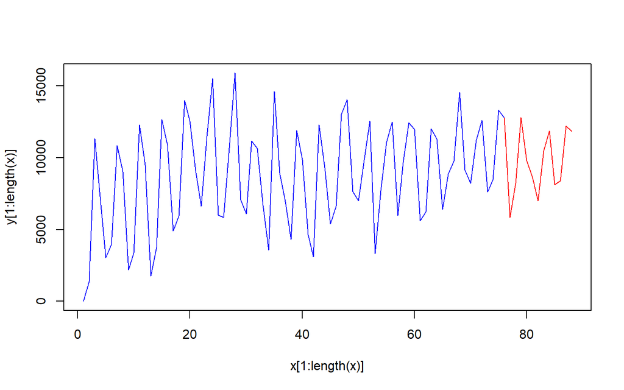

```r
pred_train<-predict(fit,inputs[-test])
pred_test <- predict(fit,inputs[-train])

# Desnormalización

valuesPred_train <- pred_train*(max(ts_data_all)-min(ts_data_all)) + min(ts_data_all)
valuesPred_test <- pred_test*(max(ts_data_all)-min(ts_data_all)) + min(ts_data_all)

x <- 1:(tamano_total+length(valuesPred_test)+4)
y <- c(as.vector(ts_data_all), valuesPred_test)

plot(x[1:length(x)], y[1:length(x)], col = "blue", type="l")
lines(x[(tamano_total):length(x)], y[(tamano_total):length(x)],col="red")
```

## 7.5 Evaluación

Por último, se evalua el modelo y se comprueba que el MAPE para train es de un 20% y para test de un 16%.

```r
# valor real y prediccion

getPerformance = function(pred, val) {
  res = pred - val
  MAE = sum(abs(res))/length(val)
  MAE_std = sd(abs(res))
  MAPE = mean(100*abs(res)/val)
  MAPE_std = sd(100*abs(res)/val)
  MSE = sum(res^2)/length(val)
  MSE_std = sd((res)**2)
  RMSE = sqrt(MSE)
  RMSE_std = sqrt(MSE_std)
  perf = data.frame(MAE,MAE_std,MAPE,MAPE_std,RMSE,RMSE_std)
}

accuracy_train_elman <- getPerformance(valuesPred_train, ts_data_all[train+4]) %>%
  mutate(Evaluation='Train Red Elman')

accuracy_test_elman <- getPerformance(valuesPred_test, ts_data_all[test+4]) %>%
  mutate(Evaluation='Test Red Elman')

bind_rows(accuracy_train_elman, accuracy_test_elman) %>% select(Evaluation, everything())
```

```
##        Evaluation      MAE  MAE_std     MAPE MAPE_std     RMSE RMSE_std
## 1 Train Red Elman 1239.407 953.6552 19.70614 25.46124 1559.556 1727.941
## 2  Test Red Elman 1418.186 910.2666 15.77143 11.99149 1654.165 1685.252
```

# 8 Elección del modelo

Por último, se comparan los resultados obtenidos con el modelo SAR implementado manualmente, el modelo SAR ajustado automáticamente, y la red neuronal Elman, para el conjunto de test. Los resultados son muy similares, sobresaliendo el test automático con 13%, frente a un 15% de error en los test manual y red neuronal.

```r
bind_rows(accuracy_test_manual, accuracy_test_automatico, accuracy_test_elman) %>% select(Evaluation, everything())
```

```
##        Evaluation      MAE   MAE_std     MAPE MAPE_std     RMSE RMSE_std
## 1     Test manual 1350.536 1061.0328 15.01943 10.24210 1689.947 2005.939
## 2 Test automatico 1280.786 1095.2968 13.27673 11.35530 1655.329 1896.219
## 3  Test Red Elman 1418.186  910.2666 15.77143 11.99149 1654.165 1685.252
```

Finalmente se decide seleccionar el modelo automático.